# Иерархические модели в RStan

Марина Дубова

`r`r library(rstan)

```
rstan (Version 2.18.2, GitRev: 2e1f913d3ca3)
For execution on a local, multicore CPU with excess RAM we recommend calling
options(mc.cores = parallel::detectCores()).
To avoid recompilation of unchanged Stan programs, we recommend calling
rstan_options(auto_write = TRUE)
```

`r`r library(ggmcmc)

`r`r library(bayesplot)

## Генерация данных

Внутригрупповой дизайн

У каждого испытуемого своё смещение, размер эффекта у всех один

`r`r N_sub <- 30 #number of subjects N_trials <- 10 #number of observations per subject per condition #population parameters sigma <- 5 #trial-by-trial error (common across Ss) intercept_mean <- 5 intercept_sd <- 8 effect_size <- 2 intercept_subj = rnorm(N_sub, intercept_mean, intercept_sd) #iterate over subjects to generate data for each one data <- NULL for(subj in 1:N_sub){ data = rbind( data , data.frame( id = subj , condition = 0 , Y = rnorm(N_trials, intercept_subj[subj], sigma) ) , data.frame( id = subj , condition = 1 , Y = rnorm(N_trials, intercept_subj[subj] + effect_size, sigma) ) ) } data$id = factor(data$id) #package the data for stan data_1 = list( nY = nrow(data) , nS = length(unique(data$id)) , Y = data$Y , cond = factor_to_contrast(data$condition) , Subj = as.numeric(data$id) )

## Модель 1

Оценка размера эффекта с учетом индивидуальных смещений

`r`r model_1 <- ’ data { int nY ; # num trials int nS ; # num subjects int Subj[nY] ; # subjects for each trial vector[nY] cond; # contrast for trial vector[nY] Y ; # outcomes } parameters { real sigma ; #trial-by-trial error real intercept ; #population-level intercept real effect ; #population-level effect real intercept_sd ; #SD of subject-to-subject deviation from the population intercept vector[nS] Sintercept ; #variable to store each subjects intercept } model { #priors on population parameters sigma ~ cauchy(0,20) ; intercept ~ normal(5,10) ; effect ~ normal(0,10) ; intercept_sd ~ cauchy(0,20) ; #assert sampling of subject-level parameters given population parameters Sintercept ~ normal(intercept,intercept_sd) ; #assert sampling of trial-by-trial data given subject-level parameters and sigma for(i in 1:nY){ Y[i] ~ normal(Sintercept[Subj[i]] + effect*cond[i] , sigma) ; } } ’

`r`r fit_1 <- stan(model_code = model_1, data = data_1)

[output not shown]

`r`r print(fit_1)

```
Inference for Stan model: 23049bca0d235e6d2ec1c4e84fabf9b0.
4 chains, each with iter=2000; warmup=1000; thin=1;
post-warmup draws per chain=1000, total post-warmup draws=4000.

                   mean se_mean   sd     2.5%      25%      50%      75%    97.5% n_eff Rhat
sigma              4.86    0.00 0.15     4.58     4.76     4.86     4.96     5.15  7428    1
intercept          5.03    0.02 1.88     1.33     3.78     5.02     6.28     8.75  7655    1
effect             2.19    0.00 0.41     1.41     1.90     2.19     2.47     2.95 10568    1
intercept_sd      10.15    0.02 1.41     7.83     9.17     9.99    10.99    13.27  6171    1
Sintercept[1]      1.04    0.01 1.04    -0.97     0.31     1.05     1.74     3.06  7968    1
Sintercept[2]     16.36    0.01 1.09    14.26    15.61    16.36    17.10    18.52  8084    1
Sintercept[3]     -5.54    0.01 1.05    -7.58    -6.25    -5.54    -4.83    -3.51  8211    1
Sintercept[4]      8.35    0.01 1.10     6.20     7.60     8.35     9.11    10.49  8352    1
Sintercept[5]      2.96    0.01 1.09     0.78     2.22     2.96     3.71     5.11  8527    1
Sintercept[6]      0.48    0.01 1.07    -1.67    -0.22     0.46     1.19     2.64  9029    1
Sintercept[7]      8.60    0.01 1.08     6.50     7.90     8.60     9.33    10.71  8218    1
Sintercept[8]      8.02    0.01 1.06     5.96     7.32     8.01     8.74    10.06  8136    1
Sintercept[9]     19.37    0.01 1.08    17.34    18.63    19.40    20.13    21.42  9681    1
Sintercept[10]     6.46    0.01 1.07     4.39     5.72     6.47     7.20     8.58  9133    1
Sintercept[11]     7.78    0.01 1.11     5.53     7.04     7.79     8.51    10.00  8914    1
Sintercept[12]   -15.45    0.01 1.10   -17.65   -16.18   -15.44   -14.73   -13.30  7639    1
Sintercept[13]     5.45    0.01 1.09     3.32     4.73     5.45     6.22     7.55  7474    1
Sintercept[14]     3.87    0.01 1.11     1.75     3.11     3.87     4.63     6.02  8003    1
Sintercept[15]    23.77    0.01 1.11    21.56    23.01    23.77    24.54    25.95  8467    1
Sintercept[16]    -5.92    0.01 1.08    -8.09    -6.64    -5.92    -5.19    -3.85  8880    1
Sintercept[17]   -11.13    0.01 1.07   -13.27   -11.85   -11.14   -10.41    -9.04  7690    1
Sintercept[18]    15.48    0.01 1.05    13.42    14.77    15.48    16.22    17.49  7637    1
Sintercept[19]     6.06    0.01 1.07     3.88     5.35     6.07     6.73     8.22  7630    1
Sintercept[20]     4.63    0.01 1.12     2.44     3.87     4.63     5.40     6.81  7969    1
Sintercept[21]     0.98    0.01 1.08    -1.12     0.27     0.98     1.70     3.16  8298    1
Sintercept[22]     4.91    0.01 1.10     2.72     4.16     4.91     5.65     7.05  8406    1
Sintercept[23]    23.61    0.01 1.07    21.56    22.89    23.61    24.34    25.70  7037    1
Sintercept[24]   -11.42    0.01 1.08   -13.54   -12.16   -11.42   -10.71    -9.32  9056    1
Sintercept[25]     5.90    0.01 1.06     3.88     5.16     5.91     6.62     7.97  8748    1
Sintercept[26]   -10.36    0.01 1.13   -12.56   -11.13   -10.36    -9.60    -8.18  8412    1
Sintercept[27]     8.54    0.01 1.06     6.47     7.83     8.54     9.24    10.58  9261    1
Sintercept[28]     8.91    0.01 1.07     6.86     8.17     8.91     9.65    11.04  7373    1
Sintercept[29]     8.08    0.01 1.09     5.96     7.37     8.09     8.84    10.19  8970    1
Sintercept[30]    10.86    0.01 1.09     8.74    10.14    10.85    11.58    13.03  8915    1
lp__           -1328.30    0.12 4.37 -1337.66 -1331.00 -1327.99 -1325.21 -1320.86  1413    1

Samples were drawn using NUTS(diag_e) at Sat Dec 29 23:49:15 2018.
For each parameter, n_eff is a crude measure of effective sample size,
and Rhat is the potential scale reduction factor on split chains (at
convergence, Rhat=1).
```

Визуализация индивидуальных смещений

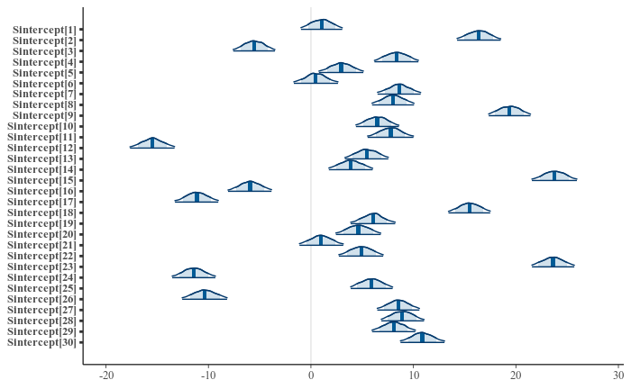

## Генерация данных

Внутригрупповой дизайн

У каждого испытуемого своё смещение и свой размер эффекта

`r`r N_sub = 30 #number of subjects N_trials = 10 #number of observations per subject per condition #population parameters sigma = 5 #trial-by-trial error (common across Ss) intercept_mean = 5 intercept_sd = 8 effect_mean = 2 effect_sd = 3 intercept_subj = rnorm(N_sub, intercept_mean, intercept_sd) effect_subj = rnorm(N_sub, effect_mean, effect_sd) #iterate over subjects to generate data for each one data = NULL for(subj in 1:N_sub){ data = rbind( data , data.frame( id = subj , condition = 0 , Y = rnorm(N_trials, intercept_subj[subj], sigma) ) , data.frame( id = subj , condition = 1 , Y = rnorm(N_trials, intercept_subj[subj] + effect_subj[subj], sigma) ) ) } data$id = factor(data$id) #package the data for stan data_1 = list( nY = nrow(data) , nS = length(unique(data$id)) , Y = data$Y , cond = factor_to_contrast(data$condition) , Subj = as.numeric(data$id) )

## Модель 2

`r`r model_1 <- ’ data { int nY ; # num trials int nS ; # num subjects int Subj[nY] ; # subjects for each trial vector[nY] cond; # contrast for trial vector[nY] Y ; # outcomes } parameters { real sigma ; #trial-by-trial error real intercept ; #population-level intercept real effect ; #population-level effect real intercept_sd ; #SD of subject-to-subject deviation from the population intercept real effect_sd ; #SD of subject-to-subject deviation from the population effect vector[nS] Sintercept ; #variable to store each subjects intercept vector[nS] Seffect ; #variable to store each subjects intercept } model { #priors on population parameters sigma ~ cauchy(0,20) ; intercept ~ normal(5,10) ; effect ~ normal(0,10) ; intercept_sd ~ cauchy(0,20) ; effect_sd ~ cauchy(0,20) ; #assert sampling of subject-level parameters given population parameters Sintercept ~ normal(intercept,intercept_sd) ; Seffect ~ normal(effect,effect_sd); #assert sampling of trial-by-trial data given subject-level parameters and sigma for(i in 1:nY){ Y[i] ~ normal(Sintercept[Subj[i]] + Seffect[Subj[i]]*cond[i] , sigma) ; } } ’

`r`r fit_1 <- stan(model_code = model_1, data = data_1)

[output not shown]

`r`r print(fit_1)

```
Inference for Stan model: c9ef1c0a9233f6d30f92353a92a55986.
4 chains, each with iter=2000; warmup=1000; thin=1;
post-warmup draws per chain=1000, total post-warmup draws=4000.

                   mean se_mean   sd     2.5%      25%      50%      75%    97.5% n_eff Rhat
sigma              4.93    0.00 0.15     4.64     4.82     4.92     5.02     5.24  5608    1
intercept          4.53    0.02 1.67     1.20     3.45     4.51     5.63     7.90  5310    1
effect             1.72    0.01 0.71     0.38     1.22     1.72     2.20     3.11  3993    1
intercept_sd       8.93    0.02 1.24     6.93     8.06     8.80     9.67    11.66  4939    1
effect_sd          3.04    0.02 0.66     1.84     2.60     3.00     3.46     4.46  1816    1
Sintercept[1]     -0.32    0.01 1.09    -2.44    -1.05    -0.30     0.42     1.80  6073    1
Sintercept[2]      0.46    0.01 1.08    -1.65    -0.29     0.46     1.19     2.57  6616    1
Sintercept[3]     11.70    0.01 1.10     9.55    10.95    11.70    12.44    13.86  7037    1
Sintercept[4]    -10.61    0.01 1.09   -12.68   -11.35   -10.60    -9.89    -8.47  5763    1
Sintercept[5]     -1.33    0.02 1.07    -3.43    -2.05    -1.32    -0.62     0.76  4683    1
Sintercept[6]    -10.23    0.01 1.07   -12.33   -10.96   -10.22    -9.50    -8.15  6178    1
Sintercept[7]      2.09    0.01 1.09    -0.03     1.37     2.09     2.80     4.20  6812    1
Sintercept[8]     -7.51    0.01 1.09    -9.70    -8.25    -7.48    -6.78    -5.38  5868    1
Sintercept[9]     -9.97    0.02 1.07   -12.08   -10.68    -9.97    -9.26    -7.78  4714    1
Sintercept[10]    16.62    0.01 1.08    14.49    15.90    16.62    17.34    18.77  6011    1
Sintercept[11]     1.89    0.01 1.06    -0.19     1.18     1.88     2.62     3.97  5319    1
Sintercept[12]    18.94    0.01 1.10    16.75    18.22    18.94    19.69    21.09  5462    1
Sintercept[13]     2.79    0.01 1.08     0.69     2.08     2.80     3.52     4.91  5508    1
Sintercept[14]     1.41    0.01 1.13    -0.79     0.68     1.43     2.17     3.59  6874    1
Sintercept[15]     6.94    0.01 1.08     4.82     6.22     6.93     7.66     9.04  6467    1
Sintercept[16]    11.43    0.01 1.12     9.24    10.67    11.45    12.19    13.62  6301    1
Sintercept[17]    15.76    0.01 1.08    13.63    15.03    15.76    16.48    17.95  7145    1
Sintercept[18]    19.96    0.01 1.08    17.81    19.20    19.96    20.69    22.07  6255    1
Sintercept[19]     0.90    0.01 1.10    -1.27     0.18     0.88     1.64     3.07  6508    1
Sintercept[20]    -0.88    0.01 1.10    -3.07    -1.59    -0.88    -0.16     1.24  6033    1
Sintercept[21]    -3.01    0.01 1.09    -5.12    -3.77    -3.03    -2.26    -0.88  5840    1
Sintercept[22]    10.09    0.01 1.08     8.01     9.33    10.07    10.85    12.15  6527    1
Sintercept[23]     1.27    0.01 1.07    -0.92     0.58     1.26     1.99     3.35  5665    1
Sintercept[24]     4.00    0.01 1.05     1.95     3.30     3.98     4.71     6.13  5793    1
Sintercept[25]     6.89    0.01 1.08     4.80     6.15     6.88     7.63     8.96  5732    1
Sintercept[26]    10.79    0.02 1.11     8.67    10.01    10.78    11.56    12.94  5130    1
Sintercept[27]    -0.82    0.02 1.08    -2.91    -1.56    -0.80    -0.10     1.27  4472    1
Sintercept[28]    11.17    0.01 1.09     9.01    10.46    11.19    11.89    13.24  6230    1
Sintercept[29]    14.30    0.01 1.07    12.22    13.58    14.28    15.02    16.36  5295    1
Sintercept[30]    10.69    0.01 1.09     8.52     9.97    10.69    11.41    12.81  5959    1
```

[output cut: 21 more lines]

```
Seffect[22]        2.34    0.02 1.80    -1.18     1.12     2.33     3.52     5.85  6389    1
Seffect[23]        3.18    0.02 1.83    -0.44     1.97     3.16     4.37     6.82  5871    1
Seffect[24]        1.30    0.02 1.79    -2.24     0.11     1.30     2.51     4.71  5816    1
Seffect[25]        1.54    0.02 1.77    -1.96     0.38     1.56     2.71     4.97  6998    1
Seffect[26]        1.52    0.02 1.75    -1.88     0.36     1.51     2.67     5.02  5433    1
Seffect[27]        0.91    0.02 1.78    -2.63    -0.27     0.94     2.08     4.42  5707    1
Seffect[28]        4.00    0.03 1.80     0.59     2.78     4.00     5.21     7.56  4869    1
Seffect[29]        4.08    0.02 1.82     0.64     2.84     4.00     5.32     7.75  5358    1
Seffect[30]        5.83    0.03 1.90     2.24     4.55     5.81     7.09     9.74  3844    1
lp__           -1378.89    0.16 6.24 -1391.97 -1382.91 -1378.54 -1374.56 -1367.35  1471    1

Samples were drawn using NUTS(diag_e) at Sat Dec 29 23:19:10 2018.
For each parameter, n_eff is a crude measure of effective sample size,
and Rhat is the potential scale reduction factor on split chains (at
convergence, Rhat=1).
```

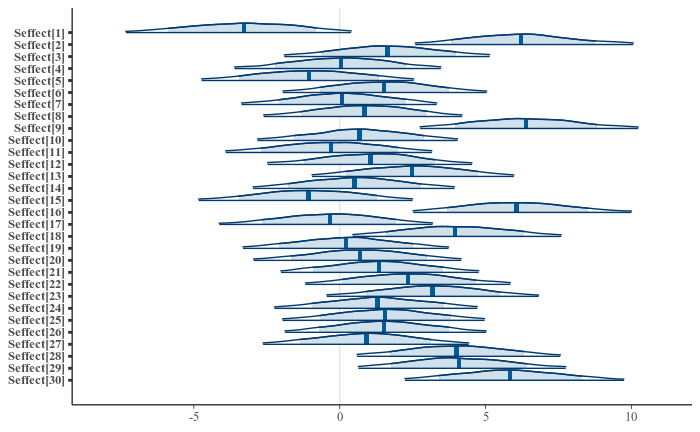

`r`r ggmcmc(D = posterior_1b, file = NULL, plot = ‘ggs_autocorrelation’) # should decline rapidly

```
Plotting autocorrelation plots
Time taken to generate the report: 17 seconds.
```

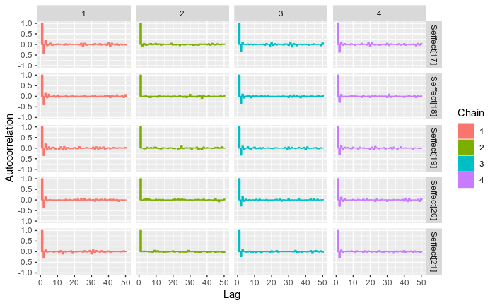

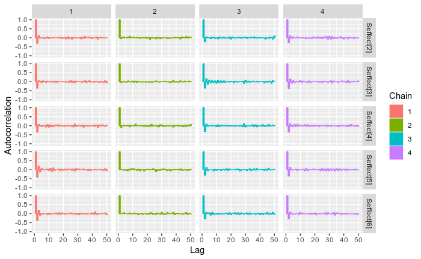

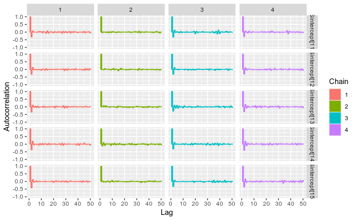

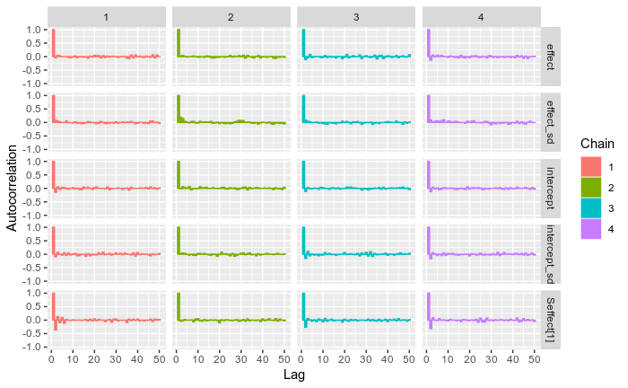

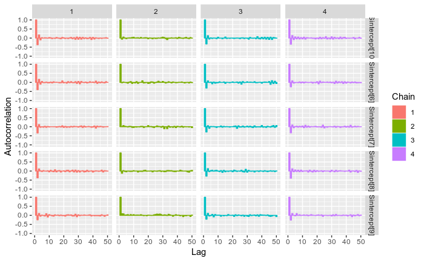

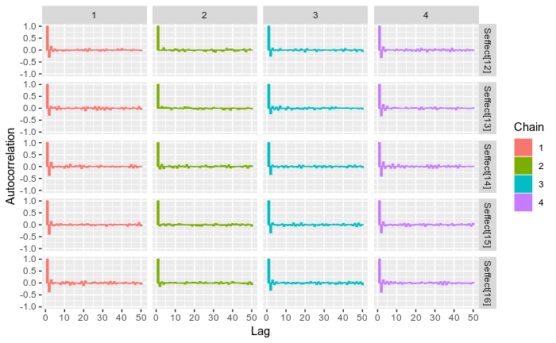

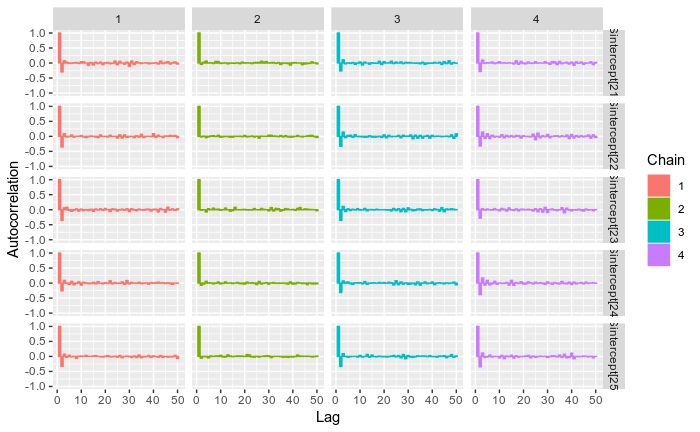

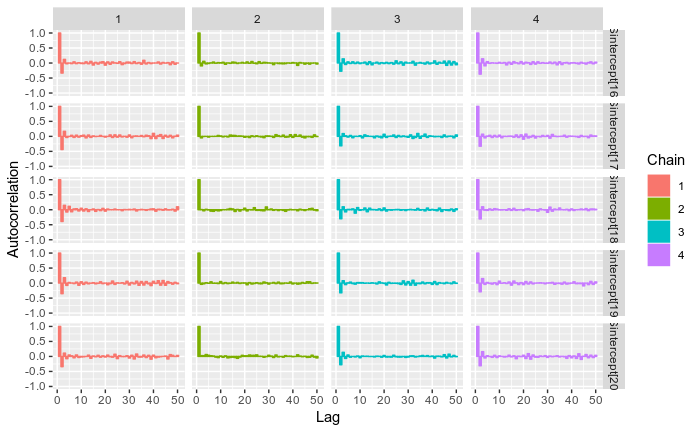

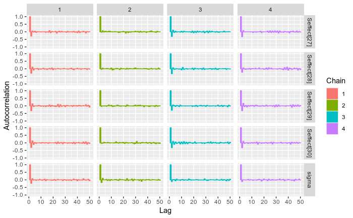

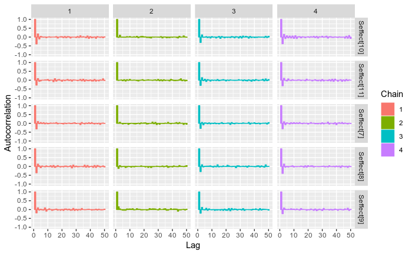

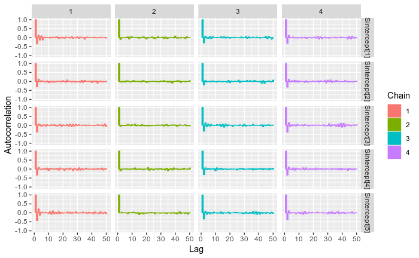

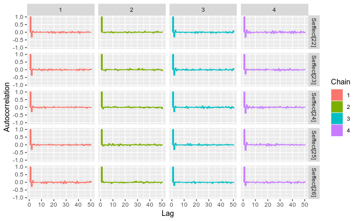

[1 more figures not shown]